# Processamento de Imagem e Visão

# Semestre de Inverno 25/26

### Trabalho prático 1

Trabalho realizado por:

- Carlos Simões, número **51696**
- Rodrigo Silva, número **51743**

**Turma 51D - Docente Pedro Mendes Jorge**

## **Índice**

1. **Introdução**
   - Contexto
   - Procedimento
2. **Processo**
3. ***Imports* e informações acerca do vídeo**
4. **Estimação de imagem de fundo**
   - Justificação do código
5. **Deteção de píxeis ativos**
   - Justificação do código
6. **Utilização de operadores morfológicos**
   - Justificação do código
7. **Deteção de regiões ativas**
   - Justificação do código
8. **Correspondência de regiões entre imagens consecutivas**
   - Justificação do código
9. **Opcional**
   - Estimação da velocidade de cada veículo
     - Justificação do código
   - Estimação da velocidade média em cada via
     - Justificação do código
10. **Visualização dos resultados do processamento**
11. **Conclusão**
12. **Bibliografia**

## **Introdução**

### Contexto

No âmbito da Unidade Curricular de Processamento de Imagem e Visão, foi solicitado o desenvolvimento de um algoritmo capaz de detetar e contar o número de veículos que circulam numa via de auto-estrada.

O principal propósito deste projeto é consolidar o domínio das funcionalidades da biblioteca `OpenCV`, aplicando simultaneamente os conceitos e técnicas introduzidos nas aulas práticas, nomeadamente no que diz respeito à deteção e classificação de objetos por computador em tempo real.

### Procedimento

1. Pretende-se desenvolver um algoritmo capaz de detectar e contar o número de veículos que circulam numa via de autoestrada. Na sequência de vídeo, deverá ser indicada uma zona (região/máscara) para a deteção de regiões ativas (veículos) onde se realiza a correspondência entre imagens consecutivas, para se proceder à contagem de veículos. Opcionalmente, poderá também estimar-se a velocidade dos veículos e a velocidade média em cada via da autoestrada.
2. Para efeitos de visualização, devem-se sobrepor à sequência original várias `BoundingBoxes`, uma para cada região ativa detetada (veículo) e um identificador que representa o seu número de ordem.
3. O código deverá ser desenvolvido em python/OpenCV.

## **Processo**

1. Estimação de imagem de fundo (Sugestão: usar filtragem temporal com filtro de mediana)
2. Deteção de píxeis ativos
3. Utilização de operadores morfológicos
4. Deteção de regiões ativas
5. Correspondência de regiões entre imagens consecutivas
6. Visualização dos resultados do processamento

## ***Imports* e informações acerca do video**

```python
import cv2 as cv
import numpy as np
import matplotlib.pyplot as plt

dados = 'AutoEstrada.avi'
video_autoestrada = cv.VideoCapture(dados)
```

```python
total_frames = int(video_autoestrada.get(cv.CAP_PROP_FRAME_COUNT))
fps = video_autoestrada.get(cv.CAP_PROP_FPS)
width = int(video_autoestrada.get(cv.CAP_PROP_FRAME_WIDTH))
height = int(video_autoestrada.get(cv.CAP_PROP_FRAME_HEIGHT))

print(f"Total de frames: {total_frames}")
print(f"FPS: {fps}")
print(f"Dimensões: {width}x{height}")
```

```
Total de frames: 234
FPS: 23.97
Dimensões: 320x240
```

## **Estimação de imagem de fundo**

A **estimação da imagem de fundo** é uma técnica utilizada em visão por computador para isolar os elementos estáticos de uma cena, removendo objetos em movimento.  
O “fundo” corresponde às partes da imagem que permanecem relativamente constantes ao longo do tempo, como por exemplo: a estrada, as marcas no pavimento, os rails de proteção, de entre outros elementos do ambiente.

Para estimar esse fundo, utilizam-se diversos métodos, sendo o utilizado a **filtragem temporal por mediana**, onde se calcula a mediana dos valores de cada pixel ao longo de vários frames do vídeo. Como objetos em movimento não ocupam a mesma posição na maioria das frames, acabam eliminados no cálculo da mediana, resultando numa imagem limpa da cena estática.

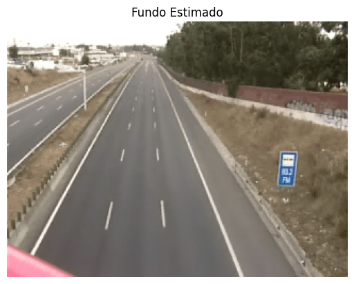

```python
def estimar_fundo_mediana(video_path):
    """
    Calcula o fundo estático do vídeo usando a mediana de N frames aleatórios.
    Isto remove os carros em movimento e deixa apenas a estrada.
    """
    cap = cv.VideoCapture(video_path) # variável para guardar o video
    total_frames = int(cap.get(cv.CAP_PROP_FRAME_COUNT)) # contagem total de frames do video

    indices = range(total_frames) # np.random.choice(total_frames, size=num_frames_amostra, replace=False)
    # Inicialmente, utilizou-se np.random.choice, pois é mais eficiente computacionalmente,
    # mas, como o video é curto, optou-se por usar todas as frames
    frames = []

    for i in indices:
        cap.set(cv.CAP_PROP_POS_FRAMES, i)
        ret, frame = cap.read()
        if ret:
            frames.append(frame)

    cap.release()

    # calcular a mediana ao longo do tempo (axis=0)
    # resultado é o "fundo ideal" sem carros
    background = np.median(np.array(frames), axis=0).astype(np.uint8)
    background_rgb = cv.cvtColor(background, cv.COLOR_BGR2RGB)
    background_gray = cv.cvtColor(background, cv.COLOR_BGR2GRAY)
    return background_gray, background_rgb

# calcular o fundo
fundo_gray, fundo_rgb = estimar_fundo_mediana(dados)

# visualizar o fundo
plt.imshow(fundo_rgb)
plt.title('Fundo Estimado')
plt.axis('off')
plt.show()
```

### Justificação do código

O método `estimar_fundo_mediana` foi implementado para obter uma imagem de fundo estática a partir de um vídeo, removendo objetos em movimento através do cálculo da mediana temporal de várias frames distribuídas ao longo da sequência.

A função funciona da seguinte maneira:

1. Abre-se o vídeo e determina-se o número total de frames disponíveis.
2. Definem-se os índices de todas as frames do vídeo (de $0$ até `total_frames`).
3. Para cada índice, posiciona-se o vídeo na frame correspondente, lê-se a mesma e adiciona-se à lista de frames.
4. Liberta-se o objeto de captura de vídeo para evitar ocupação desnecessária de recursos.
5. Calcula-se a mediana, pixel a pixel, entre todas as frames da lista, obtendo-se assim o fundo ideal sem veículos.
6. Converte-se o fundo obtido para o formato RGB, permitindo visualização correta com Matplotlib.
7. Converte-se igualmente o fundo para escala de cinzentos, útil para etapas posteriores de processamento.
8. Finalmente, devolvem-se as duas versões da imagem de fundo (grayscale e RGB) e procede-se à sua visualização.

## **Deteção de píxeis ativos**

A **deteção de píxeis ativos** é uma etapa essencial na análise de movimento em visão por computador, permitindo identificar regiões da imagem onde ocorrem alterações relativas ao fundo estático previamente estimado. Estes píxeis correspondem a objetos em movimento, que diferem significativamente dos elementos fixos.

Para detetar estes píxeis, calcula-se a **diferença absoluta** entre a imagem atual e o fundo de referência. Os valores resultantes são depois sujeitos a um processo de **binarização**, que converte diferenças relevantes numa máscara binária que indica claramente onde existe movimento. Por fim, aplica-se uma **máscara de Região de Interesse (RI)**, garantindo que apenas a área correspondente à estrada é analisada, ignorando zonas irrelevantes.

Este procedimento permite identificar a presença de veículos ou outros objetos dinâmicos na cena.

```python
# função auxiliar para criar a RI (Região de Interesse)
def get_ri_mask(shape):
    h, w = shape # altura e largura da imagem
    mask = np.zeros((h, w), dtype=np.uint8) # máscara inicializada a zeros
    # trapézio ajustado à estrada
    # pontos do trapézio
    pnt_inf_esq = [1, h] # ponto inferior esquerdo
    pnt_sup_esq = [90, 100] # ponto superior esquerdo
    pnt_sup_dir = [180, 100] # ponto superior direito
    pnt_inf_dir = [280, h] # ponto inferior direito
    # os pontos foram ajustados de maneira a que a contagem de veículos fosse mais eficaz
    pontos_trapezio = np.array([pnt_inf_esq, pnt_sup_esq, pnt_sup_dir, pnt_inf_dir], dtype=np.int32) # array dos pontos do trapézio
    cv.fillPoly(mask, [pontos_trapezio], 255) # preencher o trapézio na máscara
    return mask, pontos_trapezio

# subtração de fundo e limiarização com pré-processamento
def detetar_pixeis_ativos(frame_gray, background_gray, mask_ri):
    diff = np.abs(background_gray.astype(np.int16) - frame_gray.astype(np.int16)).astype(np.uint8)
    # a diferença absoluta entre o fundo e o frame atual serve para detetar movimento

    _, binary = cv.threshold(diff, 20, 255, cv.THRESH_BINARY)
    # inicialmente, utilizou-se Otsu para determinar o melhor limiar automaticamente, mas
    # ao testar o valor 30 (aleatoriamente escolhido) os resultados foram melhores, mas ainda assim, não satisfatórios.
    # após vários testes, o valor 20 revelou-se o mais eficaz para este cenário específico

    return cv.bitwise_and(binary, binary, mask=mask_ri)
```

### Justificação do código

O conjunto de funções apresentadas foi implementado para permitir a deteção de movimento apenas dentro da Região de Interesse, combinando a criação de uma máscara trapezoidal com a subtração de fundo e um processo de limiarização.

A lógica do código desenvolve-se da seguinte forma:

1. Define-se a função `get_ri_mask`, que gera uma máscara binária em forma de trapézio ajustado à geometria da estrada.
2. Especificam-se os quatro vértices do trapézio que delimitam a área relevante da imagem para a análise de tráfego.
3. Utiliza-se o método `cv.fillPoly` para preencher a região delimitada, produzindo a máscara final da Região de Interesse.
4. Define-se a função `detetar_pixeis_ativos`, que calcula a diferença absoluta entre o frame atual e o fundo previamente estimado, permitindo identificar alterações significativas:

$$|I_n(r,c) - B_n(r,c)|$$

5. Aplica-se um limiar fixo (20), escolhido empiricamente após diversos testes que demonstraram resultados superiores relativamente à limiarização automática por Otsu e a outros valores experimentados. A regra de decisão da binarização é:

$$I_{out}(r,c) = \begin{cases} 1 & \text{se } |I_n(r,c) - B_n(r,c)| > T \\ 0 & \text{caso contrário} \end{cases}$$

6. Converte-se esta diferença limiarizada numa máscara binária que identifica píxeis que pertencem a objetos em movimento.
7. Combina-se o resultado com a máscara da Região de Interesse através de uma operação bitwise, garantindo que apenas a área útil da cena é considerada na deteção.

Implementação baseada em: *"Capítulo 7 - Análise de Movimento: Subtração de Fundo"*

## **Utilização de operadores morfológicos**

A **morfologia matemática** é um conjunto de operações aplicadas a imagens binárias que permitem melhorar a segmentação e refinar a deteção de objetos.

No contexto da análise de movimento e deteção de veículos, estas operações são usadas para:

- **Remover ruído**: pequenos píxeis que surgem após a limiarização são eliminados.
- **Preencher buracos**: regiões de objetos segmentados que apresentam falhas ou áreas em branco são preenchidas, tornando os contornos mais consistentes.
- **Melhorar a conetividade dos objetos**: facilita o posterior rastreio ou contagem de veículos, garantindo que cada objeto é representado de forma contínua e uniforme.

As operações mais comuns são:

- **Open**, que combina erosão seguida de dilatação:

$$B \circ S = (B \ominus S) \oplus S$$

- **Close**, que realiza dilatação seguida de erosão:

$$B \bullet S = (B \oplus S) \ominus S$$

```python
def aplicar_morfologia(mask_binaria):
    # melhor opção até agora, tendo em conta os testes realizados e o threshold escolhido
    # open -> remover ruído
    kernel_open = cv.getStructuringElement(cv.MORPH_ELLIPSE, (3, 3))
    morph = cv.morphologyEx(mask_binaria, cv.MORPH_OPEN, kernel_open)
    kernel_open_small = cv.getStructuringElement(cv.MORPH_ELLIPSE, (2, 2))
    morph = cv.morphologyEx(morph, cv.MORPH_OPEN, kernel_open_small)

    # close -> preencher buracos
    kernel_close = cv.getStructuringElement(cv.MORPH_ELLIPSE, (10, 10))
    morph = cv.morphologyEx(morph, cv.MORPH_CLOSE, kernel_close)

    return morph
```

### Justificação do código

A função `aplicar_morfologia` foi implementada para melhorar a qualidade das máscaras binárias obtidas após a subtração de fundo e limiarização, removendo ruído e preenchendo buracos nos objetos detectados.

A lógica do código desenvolve-se da seguinte forma:

1. Define-se o kernel para a operação **Open** (3x3 elíptico) que remove pequenos ruídos e píxeis isolados.
2. Aplica-se a operação **Open** à máscara binária, obtendo uma versão mais limpa da imagem.
3. Define-se o kernel para a operação **Open** (2x2 elíptico) que separa carros que estejam perto um do outro.
4. Aplica-se a operação **Open**, obtendo o resultado desejado.
5. Define-se o kernel para a operação **Close** (10x10 elíptico) que preenche buracos dentro das regiões dos objetos.
6. Aplica-se a operação **Close**, consolidando os objetos detectados e melhorando os seus contornos.
7. A função devolve a máscara morfologicamente processada, pronta para passos subsequentes como contagem ou rastreio de veículos.

## **Deteção de regiões ativas**

A **deteção de regiões ativas** consiste em identificar e delimitar áreas da imagem que correspondem a objetos em movimento, a partir de uma máscara binária previamente processada.

Este procedimento permite:

- **Localizar veículos**: ao identificar as regiões da imagem onde existem píxeis ativos, é possível isolar cada objeto em movimento.
- **Filtrar ruído**: regiões muito pequenas da segmentação são descartadas com base na sua área.
- **Gerar Bounding Boxes**: para cada região válida, calcula-se o retângulo mínimo que a envolve, permitindo posteriores operações de contagem, rastreio e análise de tráfego.

A deteção de regiões ativas é um passo fundamental para transformar uma máscara binária em informação útil sobre a posição e dimensão dos objetos em movimento.

```python
def extrair_regioes(mask_binaria, area_minima, mask_zona):
    """
    Deteta os contornos na máscara binária e filtra por área
    Retorna uma lista de tuplos (x, y, w, h) que representam as Bounding Boxes

    Baseado em:
    - Extração de componentes conexos/contornos (Capítulo 3)
    - Propriedades de regiões (Área)
    - Rectângulo de fronteira (Bounding Box)
    """
    # encontrar contornos na máscara binária (contornos externos dos carros)
    contornos, _ = cv.findContours(mask_binaria, cv.RETR_EXTERNAL, cv.CHAIN_APPROX_SIMPLE)

    # lista para guardar as regiões válidas
    regioes_validas = []

    # iterar sobre os contornos encontrados
    for cnt in contornos:
        area = cv.contourArea(cnt)

        # filtro de área: ignorar regiões muito pequenas (ruído que a morfologia não tirou)
        if area > area_minima:
            # calcular a bounding box (x, y, largura, altura)
            x, y, w, h = cv.boundingRect(cnt)
            # calcular o centro do retângulo
            cx = x + w // 2
            cy = y + h // 2

            # verificar se o centro está dentro do polígono
            # a mask_zona será 'ri_mask' (máscara da região de interesse)
            try:
                if mask_zona[cy, cx] > 0:  # se o pixel for branco (>0), está dentro
                    regioes_validas.append((x, y, w, h))
            except IndexError:
                pass # ignora se o ponto cair fora dos limites da imagem

    return regioes_validas
```

### Justificação do código

A função `extrair_regioes` foi implementada para identificar e filtrar as regiões ativas detectadas numa máscara binária, criando retângulos delimitadores (Bounding Boxes) apenas para os objetos relevantes.

A lógica do código desenvolve-se da seguinte forma:

1. Aplica-se `cv.findContours` para detetar os contornos externos na máscara binária, correspondendo às regiões com movimento.
2. Inicializa-se uma lista para armazenar as regiões válidas que cumpram os critérios definidos.
3. Itera-se sobre todos os contornos encontrados, calculando a sua área com `cv.contourArea`.
4. Filtra-se os contornos cujo tamanho seja inferior a `area_minima`, eliminando ruído ou pequenas imperfeições da segmentação.
5. Calcula-se a Bounding Box de cada contorno válido, obtendo as coordenadas (x, y, largura, altura) e o centro do retângulo.
6. Verifica-se se o centro da Bounding Box se encontra dentro da **Região de Interesse (RI)**, garantindo que apenas objetos na área relevante são considerados.
7. Adicionam-se à lista de regiões válidas apenas os retângulos que passam no filtro de RI.
8. A função devolve a lista de Bounding Boxes correspondentes aos objetos em movimento dentro da área de análise, pronta para passos subsequentes como rastreio ou contagem de veículos.

## **Correspondência de regiões entre imagens consecutivas**

A **correspondência de regiões** consiste em associar os objetos detetados em frames consecutivos de um vídeo, permitindo seguir o mesmo veículo ao longo do tempo. Cada região detetada numa frame é comparada com as regiões da frame anterior para determinar se representa o mesmo objeto em movimento.

Este procedimento permite:

- **Manter a identidade dos veículos**: atribuindo IDs consistentes a cada carro, é possível seguir o percurso de cada veículo ao longo de múltiplos frames.
- **Evitar duplicações**: garante que o mesmo carro não seja contado várias vezes quando se move entre frames consecutivos.
- **Detetar carros novos ou desaparecidos**: regiões que não correspondem a carros previamente detetados são registadas como novos, enquanto veículos não correspondidos podem ser considerados como saídos da cena.

A correspondência é tipicamente baseada na **distância euclidiana entre os centros das regiões**, permitindo decidir a qual retângulo corresponde cada carro ativo.

```python
def correspondencia_regioes(carros_ativos, regioes_atuais, proximo_id, dist_max):
    """
    Atualiza o seguimento dos carros com base na proximidade (distância Euclidiana)

    Args:
        carros_ativos (dict): Dicionário com o estado anterior {id: (x,y,w,h)}
        regioes_atuais (list): Lista de tuplos detetados no frame atual [(x,y,w,h)]
        proximo_id (int): O próximo número de ID disponível
        distancia_maxima (int): Distância máxima em píxeis para considerar o mesmo carro

    Returns:
        dict: Dicionário atualizado com os carros presentes neste frame
        int: O contador de IDs atualizado
    """
    # dicionário para os carros atualizados
    novos_carros_ativos = {}

    # lista para marcar os retângulos novos que já foram associados a um carro
    indices_regioes_usadas = []

    # tentar corresponder carros que já se conhecem (carros_ativos) aos retângulos acabados de detetar (regioes_atuais)
    for id_carro, (x_ant, y_ant, w_ant, h_ant) in carros_ativos.items():
        cx_ant = x_ant + w_ant // 2 # centro x do carro anterior
        cy_ant = y_ant + h_ant // 2 # centro y do carro anterior

        melhor_distancia = dist_max # inicializar com a distância máxima permitida
        melhor_indice = -1 # índice do retângulo correspondente

        # comparar com todas as regiões novas disponíveis
        for i, (x_novo, y_novo, w_novo, h_novo) in enumerate(regioes_atuais):
            # se este retângulo já foi usado por outro carro, o mesmo é ignorado
            if i in indices_regioes_usadas:
                continue

            cx_novo = x_novo + w_novo // 2 # centro x do carro novo
            cy_novo = y_novo + h_novo // 2 # centro y do carro novo

            # cálculo da distância euclidiana (raiz quadrada da soma dos quadrados)
            dist = np.sqrt((cx_ant - cx_novo)**2 + (cy_ant - cy_novo)**2)

            if dist < melhor_distancia: # encontrar uma correspondência mais próxima
                melhor_distancia = dist # atualizar a melhor distância
                melhor_indice = i # guardar o índice do retângulo correspondente

        # se se encontrar uma correspondência válida
        if melhor_indice != -1:
            # atualiza-se a posição do carro (mantem-se o mesmo ID)
            novos_carros_ativos[id_carro] = regioes_atuais[melhor_indice]
            indices_regioes_usadas.append(melhor_indice)

    # registar carros novos
    # qualquer região que não tenha sido associada a um ID existente é um carro novo
    for i, regiao in enumerate(regioes_atuais):
        if i not in indices_regioes_usadas:
            novos_carros_ativos[proximo_id] = regiao
            proximo_id += 1

    return novos_carros_ativos, proximo_id
```

### Justificação do código

A função `correspondencia_regioes` foi implementada para atualizar o seguimento de veículos entre frames consecutivos, mantendo IDs consistentes e adicionando novos objetos quando necessário.

A lógica do código desenvolve-se da seguinte forma:

1. Inicializa-se um novo dicionário para armazenar os carros atualizados (`novos_carros_ativos`) e uma lista para marcar regiões já associadas (`indices_regioes_usadas`).
2. Para cada carro ativo previamente identificado, calcula-se o **centro da Bounding Box** do frame anterior.
3. Compara-se este centro com todas as regiões detetadas no frame atual, calculando a **distância euclidiana** entre os centros.
4. Seleciona-se a região mais próxima dentro da `dist_max` para manter o mesmo ID do carro. Se não houver correspondência, o ID não é atualizado.
5. Atualiza-se o dicionário com os carros que tiveram correspondência e marca-se o índice da região usada.
6. Para regiões não associadas a nenhum carro existente, cria-se um **novo ID**, adicionando o carro ao dicionário atualizado.
7. A função retorna o dicionário de carros atualizados e o próximo ID disponível, permitindo continuar o rastreio nos frames seguintes.

## **Opcional**

### **Transformação homográfica**

Através da transformação de perspetiva, é possível alterar o ponto de vista de uma imagem ou vídeo, obtendo uma visualização mais adequada para extrair a informação pretendida. Este processo requer a definição de dois conjuntos de pontos: os pontos de origem na imagem que se pretende analisar e os pontos de destino que delimitam a área onde a imagem transformada será apresentada.

A matriz de transformação perspetiva é então calculada a partir destes dois conjuntos de coordenadas e aplicada à imagem original, resultando numa nova visualização com a geometria ajustada.

Para tal, utilizaram-se os métodos:

- `cv2.getPerspectiveTransform`
- `cv2.warpPerspective`

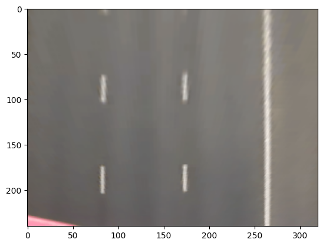

```python
# pontos do trapézio
    # pnt_inf_esq = [1, h] # ponto inferior esquerdo
    # pnt_sup_esq = [90, 100] # ponto superior esquerdo
    # pnt_sup_dir = [180, 100] # ponto superior direito
    # pnt_inf_dir = [280, h] # ponto inferior direito

# Dimensões do video: 320x240

def perspetiva_trapezio_para_retangulo(frame):
    h, w = frame.shape[:2]

    # pontos do trapézio adaptados
    pnt_inf_esq = [20, h] # ponto inferior esquerdo
    pnt_sup_esq = [90, 100] # ponto superior esquerdo
    pnt_sup_dir = [180, 100] # ponto superior direito
    pnt_inf_dir = [263, h] # ponto inferior direito

    pontos_trapezio = [pnt_inf_esq, pnt_sup_esq, pnt_sup_dir, pnt_inf_dir]

    pts1 = np.float32(pontos_trapezio)

    # pontos do output
    dst_inf_esq = [0, h]      # canto Inferior Esquerdo da imagem
    dst_sup_esq = [0, 0]      # canto Superior Esquerdo da imagem
    dst_sup_dir = [w, 0]      # canto Superior Direito da imagem
    dst_inf_dir = [w, h]      # canto Inferior Direito da imagem

    pts2 = np.float32([dst_inf_esq, dst_sup_esq, dst_sup_dir, dst_inf_dir])

    matrix = cv.getPerspectiveTransform(pts1, pts2) # transformação homográfica
    resultado = cv.warpPerspective(frame, matrix, (w, h)) # aplicar a transformação

    return resultado

# aplicar a perspetiva
fundo_perspectiva = perspetiva_trapezio_para_retangulo(fundo_rgb)
plt.imshow(fundo_perspectiva)
```

### Justificação do código

O método `perspetiva_trapezio_para_retangulo`, como o próprio nome indica, faz a transformação homográfica da região de interesse original colocando-a numa perspetiva vista de cima. Esta transformação é essencial para facilitar o cálculo de distâncias reais.

Este foi desenvolvido de maneira a receber uma frame do vídeo e:

1. Obter as dimensões da imagem original (altura `h` e largura `w`), ou seja, da frame passada como parâmetro;
2. Definir, novamente, os quatro pontos da região de interesse, mas adaptados de maneira a ficar um retângulo;
3. Armazenar esses pontos num NumPy Array do tipo `float32`;
4. De seguida, criar um NumPy Array do tipo `float32` para armazenar os pontos da imagem final;
5. Calcular a matriz de transformação utilizando `cv.getPerspectiveTransform`;
6. Aplicar a transformação à imagem através do `cv.warpPerspective`, que mapeia cada pixel da imagem original para a nova perspetiva retangular
7. Retornar a imagem transformada

```python
# código implementado para debug -> marcar pontos manualmente na imagem para medir distâncias

# pontos_clicados = []

# def desenhar_ponto(event, x, y, flags, param):
#     if event == cv.EVENT_LBUTTONDOWN:
#         pontos_clicados.append((x, y))
#         print(f"Ponto adicionado: ({x}, {y})")
#         cv.circle(param, (x, y), 5, (0, 0, 255), -1)
#         cv.putText(param, f"({x},{y})", (x+10, y),
#                    cv.FONT_HERSHEY_SIMPLEX, 0.4, (0, 255, 0), 1)
#         cv.imshow('Clica para marcar pontos', param)

# # Usar
# img_debug = fundo_perspectiva.copy()
# cv.setMouseCallback('Marca pontos', desenhar_ponto, img_debug)
# cv.imshow('Marca pontos', img_debug)
# cv.waitKey(0)
# cv.destroyAllWindows()

# print("Pontos clicados:", pontos_clicados)

# comentou-se este bloco de código pois este foi apenas utilizado para perceber a distância em píxeis entre o ínicio de um traço e o ínicio do seguinte
```

Com a função `desenhar_ponto`, conseguiu-se perceber que a distância desde o ínicio de um traço da linha descontínua até ao início do seguinte são $100px$. Segundo o IMT, uma linha descontínua na autoestrada contém traços de $4m$ de comprimento e intervalos entre eles de $10m$, que no total dá $14m$. Ou seja, $14m$ na imagem de perspetiva correspondem a $100px$.

### **Estimação da velocidade de cada veículo**

O objetivo é converter o movimento detetado no ecrã (em píxeis) para uma grandeza física no mundo real (km/h). Como a câmara está fixa, o deslocamento de um centróide entre frames corresponde a uma distância física percorrida num determinado intervalo de tempo.

```python
def tempo(frame_inicio, frame_fim, fps):
    return (frame_fim - frame_inicio) / fps  # cálculo do tempo em segundos entre dois frames
# no caso deste vídeo, fps = 23.97

def velocidade(dist, tempo): # fórmula da velocidade, convertendo-a para km/h
    velocidade_ms = dist / tempo # velocidade em m/s
    velocidade_kmh = velocidade_ms * 3.6 # converter para km/h
    return velocidade_kmh

def velocidade_veiculo(frame_inicio, frame_fim, fps, dist):
    t = tempo(frame_inicio, frame_fim, fps)
    if t == 0:
        return 0 # evitar divisão por zero
    v = velocidade(dist, t)
    return v

fator_conversao = 14.0/100.0 # metros por pixel (14 metros em 100 pixels)

def calcular_distancia_real(ponto_a, ponto_b, metros_por_pixel):
    dist_pixels = np.sqrt((ponto_b[0] - ponto_a[0])**2 + (ponto_b[1] - ponto_a[1])**2)
    return dist_pixels * metros_por_pixel
```

### Justificação do código

A função `tempo` foi implementada para calcular o tempo decorrido entre duas frames. O mesmo aplica a seguinte fórmula:

$$\Delta t = \frac{\text{Frame}_{fim} - \text{Frame}_{inicio}}{\text{FPS}}$$

O método `velocidade` foi implementado segundo a fórmula:

$$v = \frac{\Delta d}{\Delta t}$$

O método `velocidade_veiculo` calcula a velocidade de um veículo entre dois instantes (frames) a partir da distância percorrida e do tempo decorrido, retornando o resultado em km/h, utilizando as funções anteriormente definidas.

Por fim, desenvolveu-se a função `calcular_distancia_real`, cujo objetivo é converter a distância medida em píxeis para a distância real em metros. A função calcula primeiro a distância euclidiana em píxeis entre dois pontos e depois multiplica-a pelo fator de conversão metros_por_pixel, permitindo assim obter a distância física percorrida pelo veículo na estrada.

### **Estimação da velocidade média em cada via**

Para além da velocidade individual, pretende-se caracterizar o fluxo de trânsito. Isto implica segmentar o espaço da estrada em "vias" e calcular estatísticas agregadas para cada uma.

```python
def identificar_via(cx, w):
    # dividir a região em 3 vias aproximadamente iguais
    # ajustar os limites conforme a região de interesse do trapézio
    limite_esquerda = 90   # aproximadamente 1/3 da largura útil
    limite_direita = 180   # aproximadamente 2/3 da largura útil

    if cx < limite_esquerda:
        return 0  # via esquerda
    elif cx < limite_direita:
        return 1  # via centro
    else:
        return 2  # via direita

def calcular_velocidade_media_vias(velocidades_por_via):
    velocidade_media = {}
    for via in range(3):
        if len(velocidades_por_via[via]) > 0:
            velocidade_media[via] = np.mean(velocidades_por_via[via])
        else:
            velocidade_media[via] = 0
    return velocidade_media
```

### Justificação do código

Primeiramente, implementou-se a função `identificar_via` que, como o próprio nome indica, determina em que via da autoestrada se encontra cada veículo com base na coordenada horizontal do seu centro. A estrada foi dividida em três vias (esquerda, centro e direita) através de limites definidos empiricamente que correspondem à geometria da região de interesse trapezoidal. A função retorna um identificador numérico (0, 1 ou 2) que representa a via onde o veículo circula.

De seguida, criou-se a função `calcular_velocidade_media_vias` que calcula a velocidade média de todos os veículos registados em cada uma das três vias. Para cada via, verifica-se se existem velocidades registadas e, em caso afirmativo, calcula-se a média aritmética desses valores. Caso não existam dados para uma determinada via, atribui-se o valor zero, indicando ausência de informação.

## **Visualização dos resultados do processamento**

Como se optou por calcular as velocidades dos carros e as velocidades médias de cada via, o vídeo terá que estar em perspetiva.

```python
def main_visualizacao_loop(modo_visualizacao):
    video_path = 'AutoEstrada.avi'

    background_gray, _ = estimar_fundo_mediana(video_path)
    h, w = background_gray.shape
    ri_mask, ri_pts = get_ri_mask((h, w))

    # aplicar perspetiva ao fundo
    background_bgr = cv.merge([background_gray, background_gray, background_gray])
    background_bgr = perspetiva_trapezio_para_retangulo(background_bgr)
    background_gray = cv.cvtColor(background_bgr, cv.COLOR_BGR2GRAY)
    ri_mask = np.ones((h, w), dtype=np.uint8) * 255

    cap = cv.VideoCapture(video_path)
    print("carregar no 'v' para mudar a visualização")
    print("carregar no 'q' para sair")

    carros_ativos = {} # dicionário para os carros atualmente registados (id: (x,y,w,h))
    proximo_id = 0 # próximo ID disponível
    dist_max = 25 # distância máxima em píxeis para correspondência de carros

    ids_contados = [] # lista de IDs já contados
    total_veiculos = 0 # contador total de veículos

    fps = 23.97 # frames por segundo do vídeo

    velocidade_video = int(1000 / fps) # intervalo de tempo entre frames em milissegundos

    carros_primeiro_frame = {}   # dicionário para guardar o primeiro frame em que cada carro foi detetado {id: frame_numero_inicial}
    carros_posicao_inicial = {}  # dicionário para guardar a posição inicial de cada carro {id: (cx_inicial, cy_inicial)}
    carros_velocidade = {}       # dicionário para guardar a velocidade atual de cada carro {id: velocidade_atual_kmh}

    carros_via = {}  # {id_carro: numero_da_via (0, 1 ou 2)}
    velocidades_por_via = {0: [], 1: [], 2: []}  # {via: [lista de velocidades]}
    carros_velocidade_registada = set()  # IDs de carros já contabilizados

    frame_atual = 0 # contador de frames atual

    while True:
        ret, frame = cap.read() # ler o próximo frame

        # reiniciar o video em loop
        if not ret:
            cap.set(cv.CAP_PROP_POS_FRAMES, 0) # voltar ao início
            ret, frame = cap.read() # ler o primeiro frame
            if not ret: break # sair se não for possível ler o frame

            # reset das variáveis ao acabar o video
            carros_ativos = {}
            proximo_id = 0
            ids_contados = []
            total_veiculos = 0
            carros_primeiro_frame = {}
            carros_posicao_inicial = {}
            carros_velocidade = {}
            carros_via = {}
            velocidades_por_via = {0: [], 1: [], 2: []}
            carros_velocidade_registada = set()
            frame_atual = 0

        frame_atual += 1 # incrementar o contador de frames

        frame = perspetiva_trapezio_para_retangulo(frame)

        # processamento de Imagem
        frame_gray = cv.cvtColor(frame, cv.COLOR_BGR2GRAY)

        # deteção de píxeis
        mask_bruta = detetar_pixeis_ativos(frame_gray, background_gray, ri_mask)

        # morfologia
        mask_limpa = aplicar_morfologia(mask_bruta)

        # deteção de regiões (Bounding Boxes)
        lista_bounding_boxes = extrair_regioes(mask_limpa, 100, ri_mask)

        # correspondência de regiões (Tracking)
        carros_ativos, proximo_id = correspondencia_regioes(carros_ativos, lista_bounding_boxes, proximo_id, dist_max)

        # lógica de contagem e velocidade
        # contagem
        for id_carro in carros_ativos:
            if id_carro not in ids_contados:
                total_veiculos += 1
                ids_contados.append(id_carro)

        # cálculo de velocidade
        for id_carro, (x, y, w, h) in carros_ativos.items():
            cx = x + w // 2
            cy = y + h // 2
            pos_atual = (cx, cy)

            if id_carro not in carros_via:
                carros_via[id_carro] = identificar_via(cx, w)
            # se é a primeira vez que se vê o carro, guarda-se o estado inicial
            if id_carro not in carros_posicao_inicial:
                carros_primeiro_frame[id_carro] = frame_atual
                carros_posicao_inicial[id_carro] = pos_atual
                carros_velocidade[id_carro] = 0
            else:
                # recuperar a posição inicial
                pos_inicial = carros_posicao_inicial[id_carro]

                # calcular a distância percorrida em metros
                dist_metros = calcular_distancia_real(pos_inicial, pos_atual, fator_conversao)

                # verificar se se passou tempo suficiente para evitar ruído (ex: > 0.2s)
                tempo_decorrido = tempo(carros_primeiro_frame[id_carro], frame_atual, fps)

                if tempo_decorrido > 0.2:
                    velocidade_kmh = velocidade_veiculo(carros_primeiro_frame[id_carro], frame_atual, fps, dist_metros)
                    if 10 < velocidade_kmh < 200:  # filtro de valores realistas
                        carros_velocidade[id_carro] = velocidade_kmh

                        # registar velocidade apenas uma vez por carro
                        if id_carro not in carros_velocidade_registada:
                            via = carros_via[id_carro]
                            velocidades_por_via[via].append(velocidade_kmh)
                            carros_velocidade_registada.add(id_carro)

        velocidade_media = calcular_velocidade_media_vias(velocidades_por_via)

        # visualização
        key = cv.waitKey(velocidade_video) & 0xFF
        if key == ord('q'):
            break
        elif key == ord('v'):
            modo_visualizacao = (modo_visualizacao + 1) % 4

        if modo_visualizacao == 0:
            img_show = frame.copy()
            # cv.polylines(img_show, [ri_pts], True, (0, 255, 0), 1)
            texto = "1. Original"

        elif modo_visualizacao == 1:
            img_show = mask_bruta
            texto = "2. Detecao de Pixeis Ativos"

        elif modo_visualizacao == 2:
            img_show = mask_limpa
            texto = "3. Morfologia"

        elif modo_visualizacao == 3:
            img_show = frame.copy()

            #cv.polylines(img_show, [ri_pts], True, (0, 255, 0), 1)

            for id_carro, (x, y, w, h) in carros_ativos.items():
                cx, cy = x + w // 2, y + h // 2

                cv.rectangle(img_show, (x, y), (x + w, y + h), (0, 255, 0), 2)
                cv.circle(img_show, (cx, cy), 4, (0, 255, 0), -1)

                vel = carros_velocidade.get(id_carro, 0)
                label_text = f"ID:{id_carro}"
                if vel > 0:
                    label_text += f" {vel:.0f}km/h"

                cv.putText(img_show, label_text, (x, y - 10),
                           cv.FONT_HERSHEY_SIMPLEX, 0.5, (0, 255, 0), 2)

            # painel de contagem
            painel_altura = 40
            painel_largura = 150
            margem_topo = 50

            cv.rectangle(img_show, (320 - painel_largura, margem_topo), (320, margem_topo + painel_altura), (0, 0, 0), -1)
            cv.putText(img_show, f"Total: {total_veiculos}", (320 - painel_largura + 10, margem_topo + 25),
                    cv.FONT_HERSHEY_SIMPLEX, 0.7, (255, 255, 255), 2)

            posicoes_vias = [30, 120, 200]  # esquerda, centro, direita
            y_texto = 230  # posição vertical

            for via in range(3):
                vel_media = velocidade_media[via]
                if vel_media > 0:
                    texto_via = f"{vel_media:.0f}"
                else:
                    texto_via = "--"

                x_texto = posicoes_vias[via]

                # desenhar outline com contorno preto
                cv.putText(img_show, texto_via, (x_texto, y_texto),
                        cv.FONT_HERSHEY_SIMPLEX, 0.5, (0, 0, 0), 5)

                # desenhar texto principal a branco
                cv.putText(img_show, texto_via, (x_texto, y_texto),
                        cv.FONT_HERSHEY_SIMPLEX, 0.5, (255, 255, 255), 2)

            texto = "4. Detecao e Tracking"

        if len(img_show.shape) == 2:
            img_show = cv.cvtColor(img_show, cv.COLOR_GRAY2BGR)

        cv.putText(img_show, texto, (10, 30), cv.FONT_HERSHEY_SIMPLEX, 0.45, (0, 0, 0), 6)
        cv.putText(img_show, texto, (10, 30), cv.FONT_HERSHEY_SIMPLEX, 0.45, (0, 0, 255), 2)
        cv.imshow('"q"->sair, "v"->mudar modo', img_show)

    cap.release()
    cv.destroyAllWindows()

if __name__ == "__main__":
    # 0: original, 1: deteção de pixéis ativos, 2: morfologia, 3: deteção e tracking
    modo = 3
    main_visualizacao_loop(modo)
```

```
carregar no 'v' para mudar a visualização
carregar no 'q' para sair
```

## **Conclusão**

Este projeto permitiu consolidar a aplicação de técnicas de visão por computador, como a subtração de fundo, operações morfológicas e transformação de perspetiva.

## **Bibliografia**

OpenCV - https://opencv.org

OpenCV Documentation - https://docs.opencv.org/4.x/index.html

GeeksforGeeks:

- OpenCV Tutorial in Python: https://www.geeksforgeeks.org/python/opencv-python-tutorial
- Perspective Transformation - Python OpenCV: https://www.geeksforgeeks.org/python/perspective-transformation-python-opencv/

Acetatos disponibilizados pelo docente no Moodle da disciplina